# When u got alotta many categorical vars

So back when we started cleaning the variables, to try to reduce the dimensionality of this data set, there are alot of incredibly unbalanced variables. This means that class occurance of the non-primary class is so low that they almost have no variance.

Conventional wisdom dictates to just removed these in order to avoid having alot of low variance predictors. However, as I was decimating the data I was begining to wonder if this is always correct.

So I decided to see where loss occurs, and by this I mean where the most loss occurs so that we can see if removing those low-var predictors is reasonable.

For most of my EDA I used this kernel: https://www.kaggle.com/sharmasanthosh/allstate-claims-severity/exploratory-study-on-ml-algorithms

Of which, I primarily looked at the histograms of the categorical variables to see which were unbalanced

```python
import numpy as np
import pandas as pd
import matplotlib.pyplot as plt
import seaborn as sns
%matplotlib inline
```

```python
#read in the data
dt = pd.read_csv('ohf.csv')
dt.drop('id', axis = 1, inplace = True)

dt.shape
```

```
(188318, 1154)
```

As you can see below this is a very skewed response. There is a huge difference between mean and median, along with sizeable 3rd and 4th moments. It has a long but not too fat (call it husky) tail.

```
count    188318.000000
mean       3037.337686
std        2904.086186
min           0.670000
25%        1204.460000
50%        2115.570000
75%        3864.045000
max      121012.250000
Name: loss, dtype: float64
med 2115.5699999999997
mode 0    580.0
dtype: float64
skew 3.79495837754
kurt 48.0795678254
```

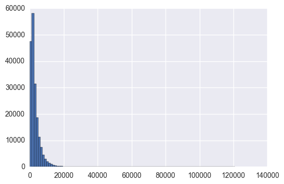

```python
dt.loss.hist(bins = 100)
print(dt.loss.describe())
print('med', dt.loss.median())
print('mode', dt.loss.mode())
print('skew', dt.loss.skew())
print('kurt', dt.loss.kurtosis())
```

Below I am going to create a categorical variable based upon which quantile of loss the observation falls into

```python
#create a categorical variable based on quantile of loss (severity)
from sklearn.preprocessing import LabelEncoder

le = LabelEncoder()
quant = le.fit_transform(pd.cut(dt.loss,4))
print(le.classes_)

dt['quant'] = quant

#make a list of vars to remove
conts = [i for i in dt.columns if "cont" in i]
conts.append('loss')
conts.append('quant')

quant = dt.quant
```

```
['(-120.342, 30253.565]' '(30253.565, 60506.46]' '(60506.46, 90759.355]'
 '(90759.355, 121012.25]']
```

So you can see that the upper bins are big and no where close to the mean. This is saying that there are gonna be outliers and my hunch is that all of those unbalanced variabels are going to contain informatuon about outliers with them occuring in one of those non-primary classes.

One other method for this I would ty would be to train a 4 classed classifier to predict what bin the response will fall in because that is easier, and if that classification has small amounts of error, predict it's output and then include that variable in the regression method that you are using.

That wasn't the best explanation, but the gist is:

```
Outliers ain't gonna be outliers in loss and nothing else
```

```python
#calculate the avg. quantile by class of var
sev = []
for i in dt.drop(conts, axis=1).columns:
    if dt[i][dt[i] > 0].sum() > 10:
        sev.append((i,np.sum(dt[i]*quant)/(dt[i][dt[i] > 0].sum())))
```

```python
#create a dataframe of the the score
score = pd.DataFrame(sev)
score.columns = ['name', 'val']
score.index = score.name

#get the top 100 vars for quantile metric
smscore = score.sort_values('val', ascending=False).iloc[0:100,]
```

```python
#grab some results vars
mns = []
sds = []
ns = []
total = []
for name in smscore.index:
    mns.append(dt[dt[name] > 0].loss.mean())
    sds.append(dt[dt[name] > 0].loss.std())
    ns.append(len(dt[dt[name] > 0]))
    total.append(dt[dt[name] > 0].loss.sum())

smscore['avg_loss'] = mns
smscore['std_loss'] = sds
smscore['ocs'] = ns
smscore['sum_loss'] = total
```

```python
#sort on the avg loss per var occurance
smscore.sort_values("avg_loss", ascending=False)
```

| name | name | val | avg_loss | std_loss | ocs | sum_loss |
| --- | --- | --- | --- | --- | --- | --- |
| cat113_U | cat113_U | 0.636364 | 36429.880000 | 41482.439372 | 11 | 4.007287e+05 |
| cat115_E | cat115_E | 0.545455 | 29163.914545 | 42837.542020 | 11 | 3.208031e+05 |
| cat105_P | cat105_P | 0.466667 | 22600.972000 | 38906.094859 | 15 | 3.390146e+05 |
| cat116_U | cat116_U | 0.357143 | 20924.859286 | 27403.803917 | 14 | 2.929480e+05 |
| cat113_G | cat113_G | 0.333333 | 20191.357222 | 25733.199661 | 18 | 3.634444e+05 |
| cat57_B | cat57_B | 0.006949 | 10239.967773 | 5298.800662 | 3022 | 3.094518e+07 |
| cat116_MR | cat116_MR | 0.105263 | 9178.802632 | 12913.925397 | 19 | 1.743973e+05 |
| cat101_S | cat101_S | 0.005780 | 8993.138439 | 5099.103568 | 173 | 1.555813e+06 |
| cat114_V | cat114_V | 0.030303 | 8858.997273 | 6810.453743 | 33 | 2.923469e+05 |
| cat101_R | cat101_R | 0.014493 | 8564.376594 | 5604.686693 | 138 | 1.181884e+06 |
| cat89_B | cat89_B | 0.004174 | 8213.293627 | 5524.873475 | 4312 | 3.541572e+07 |
| cat7_B | cat7_B | 0.004591 | 8195.078524 | 5530.075731 | 4574 | 3.748429e+07 |
| cat116_H | cat116_H | 0.052632 | 8076.843158 | 9240.504682 | 19 | 1.534600e+05 |
| cat89_C | cat89_C | 0.013636 | 7803.455545 | 5537.657644 | 220 | 1.716760e+06 |
| cat103_I | cat103_I | 0.009174 | 7276.575963 | 5277.131591 | 109 | 7.931468e+05 |
| cat101_Q | cat101_Q | 0.002172 | 7057.470264 | 4651.853554 | 2762 | 1.949273e+07 |
| cat105_N | cat105_N | 0.015625 | 7031.065469 | 5495.233526 | 64 | 4.499882e+05 |
| cat116_MK | cat116_MK | 0.035714 | 6960.207857 | 8656.197759 | 28 | 1.948858e+05 |
| cat101_O | cat101_O | 0.001604 | 6870.387172 | 4215.629488 | 2493 | 1.712788e+07 |
| cat106_C | cat106_C | 0.062016 | 6771.240543 | 12499.845857 | 129 | 8.734900e+05 |
| cat105_L | cat105_L | 0.027586 | 6631.494759 | 7454.698054 | 145 | 9.615667e+05 |
| cat116_KT | cat116_KT | 0.021277 | 6609.439681 | 7794.244884 | 94 | 6.212873e+05 |
| cat111_Q | cat111_Q | 0.010989 | 6552.888901 | 4418.398455 | 91 | 5.963129e+05 |
| cat116_LV | cat116_LV | 0.023490 | 6542.849530 | 7819.745719 | 298 | 1.949769e+06 |
| cat116_GW | cat116_GW | 0.023810 | 6464.232857 | 7880.830385 | 84 | 5.429956e+05 |
| cat114_U | cat114_U | 0.004000 | 6385.025760 | 4649.103776 | 250 | 1.596256e+06 |
| cat116_LT | cat116_LT | 0.020833 | 6315.619167 | 6049.394491 | 48 | 3.031497e+05 |
| cat79_D | cat79_D | 0.002063 | 6311.832058 | 4449.475321 | 26657 | 1.682545e+08 |
| cat105_M | cat105_M | 0.017544 | 6275.504035 | 9048.899294 | 171 | 1.073111e+06 |
| cat87_D | cat87_D | 0.001707 | 6134.342702 | 4184.565356 | 11719 | 7.188836e+07 |
| ... | ... | ... | ... | ... | ... | ... |
| cat105_I | cat105_I | 0.003060 | 4356.198208 | 4618.690627 | 2941 | 1.281158e+07 |
| cat113_F | cat113_F | 0.002734 | 4289.362775 | 4370.231172 | 1463 | 6.275338e+06 |
| cat116_GB | cat116_GB | 0.004149 | 4188.109461 | 4656.912894 | 241 | 1.009334e+06 |
| cat104_M | cat104_M | 0.005190 | 4167.185519 | 4954.369684 | 1156 | 4.817266e+06 |
| cat115_G | cat115_G | 0.015873 | 4106.091397 | 5953.356760 | 315 | 1.293419e+06 |
| cat79_C | cat79_C | 0.001799 | 4086.994281 | 3992.885665 | 1668 | 6.817106e+06 |
| cat19_B | cat19_B | 0.001659 | 4072.091112 | 3499.586558 | 1808 | 7.362341e+06 |
| cat92_B | cat92_B | 0.001592 | 4045.454315 | 3671.028824 | 628 | 2.540545e+06 |
| cat113_H | cat113_H | 0.001570 | 4008.189835 | 4327.285657 | 5094 | 2.041772e+07 |
| cat99_E | cat99_E | 0.005803 | 3964.889942 | 5600.407354 | 1034 | 4.099696e+06 |
| cat113_AI | cat113_AI | 0.002273 | 3903.627227 | 4199.090593 | 440 | 1.717596e+06 |
| cat108_H | cat108_H | 0.004413 | 3878.650778 | 4820.423756 | 4305 | 1.669759e+07 |
| cat104_N | cat104_N | 0.006536 | 3861.095621 | 5292.216971 | 153 | 5.907476e+05 |
| cat71_B | cat71_B | 0.002378 | 3832.638352 | 4183.913825 | 9672 | 3.706928e+07 |
| cat116_MJ | cat116_MJ | 0.005706 | 3803.600371 | 4432.553291 | 701 | 2.666324e+06 |
| cat108_E | cat108_E | 0.001381 | 3771.103086 | 4046.290668 | 7968 | 3.004815e+07 |
| cat108_D | cat108_D | 0.001566 | 3719.431096 | 3998.122754 | 19160 | 7.126430e+07 |
| cat104_L | cat104_L | 0.003729 | 3683.609644 | 4134.880611 | 3486 | 1.284106e+07 |
| cat106_E | cat106_E | 0.001846 | 3538.742397 | 3869.408932 | 13000 | 4.600365e+07 |
| cat95_A | cat95_A | 0.002944 | 3530.309422 | 4362.294220 | 3736 | 1.318924e+07 |
| cat110_CL | cat110_CL | 0.001541 | 3523.730538 | 3782.265174 | 25305 | 8.916800e+07 |
| cat100_O | cat100_O | 0.001580 | 3496.489035 | 3809.167439 | 5697 | 1.991950e+07 |
| cat116_KJ | cat116_KJ | 0.007692 | 3451.036000 | 3828.111835 | 130 | 4.486347e+05 |
| cat99_F | cat99_F | 0.001850 | 3364.004367 | 3770.832141 | 2702 | 9.089540e+06 |
| cat115_H | cat115_H | 0.002148 | 3336.945456 | 3980.354311 | 2793 | 9.320089e+06 |
| cat115_I | cat115_I | 0.001551 | 2991.019257 | 3208.069463 | 7090 | 2.120633e+07 |
| cat107_E | cat107_E | 0.002077 | 2871.429175 | 3316.108138 | 12521 | 3.595316e+07 |
| cat112_Q | cat112_Q | 0.002522 | 2843.746015 | 3740.050461 | 793 | 2.255091e+06 |
| cat107_D | cat107_D | 0.003101 | 2636.230164 | 3909.559544 | 3225 | 8.501842e+06 |
| cat107_C | cat107_C | 0.004695 | 2076.430704 | 3673.600367 | 213 | 4.422797e+05 |

100 rows × 6 columns

```python
smscore['cv'] = smscore.avg_loss / smscore.std_loss
```

```python
smscore.sort_values('cv', ascending=False)
```

| name | name | val | avg_loss | std_loss | ocs | sum_loss | cv |
| --- | --- | --- | --- | --- | --- | --- | --- |
| cat57_B | cat57_B | 0.006949 | 10239.967773 | 5298.800662 | 3022 | 3.094518e+07 | 1.932507 |
| cat101_S | cat101_S | 0.005780 | 8993.138439 | 5099.103568 | 173 | 1.555813e+06 | 1.763670 |
| cat101_O | cat101_O | 0.001604 | 6870.387172 | 4215.629488 | 2493 | 1.712788e+07 | 1.629742 |
| cat16_B | cat16_B | 0.001390 | 5977.987375 | 3801.805857 | 6475 | 3.870747e+07 | 1.572407 |
| cat101_R | cat101_R | 0.014493 | 8564.376594 | 5604.686693 | 138 | 1.181884e+06 | 1.528074 |
| cat101_Q | cat101_Q | 0.002172 | 7057.470264 | 4651.853554 | 2762 | 1.949273e+07 | 1.517131 |
| cat89_B | cat89_B | 0.004174 | 8213.293627 | 5524.873475 | 4312 | 3.541572e+07 | 1.486603 |
| cat111_Q | cat111_Q | 0.010989 | 6552.888901 | 4418.398455 | 91 | 5.963129e+05 | 1.483091 |
| cat7_B | cat7_B | 0.004591 | 8195.078524 | 5530.075731 | 4574 | 3.748429e+07 | 1.481911 |
| cat87_D | cat87_D | 0.001707 | 6134.342702 | 4184.565356 | 11719 | 7.188836e+07 | 1.465945 |
| cat101_M | cat101_M | 0.002180 | 5540.292766 | 3895.336013 | 3669 | 2.032733e+07 | 1.422289 |
| cat79_D | cat79_D | 0.002063 | 6311.832058 | 4449.475321 | 26657 | 1.682545e+08 | 1.418556 |
| cat111_M | cat111_M | 0.004228 | 6090.626152 | 4306.739422 | 473 | 2.880866e+06 | 1.414208 |
| cat89_C | cat89_C | 0.013636 | 7803.455545 | 5537.657644 | 220 | 1.716760e+06 | 1.409162 |
| cat103_I | cat103_I | 0.009174 | 7276.575963 | 5277.131591 | 109 | 7.931468e+05 | 1.378888 |
| cat114_U | cat114_U | 0.004000 | 6385.025760 | 4649.103776 | 250 | 1.596256e+06 | 1.373389 |
| cat90_C | cat90_C | 0.004121 | 6116.228049 | 4461.620059 | 728 | 4.452614e+06 | 1.370854 |
| cat111_O | cat111_O | 0.004525 | 6091.215928 | 4567.558201 | 221 | 1.346159e+06 | 1.333583 |
| cat87_C | cat87_C | 0.002154 | 5969.474562 | 4511.362583 | 8819 | 5.264480e+07 | 1.323209 |
| cat114_V | cat114_V | 0.030303 | 8858.997273 | 6810.453743 | 33 | 2.923469e+05 | 1.300794 |
| cat105_N | cat105_N | 0.015625 | 7031.065469 | 5495.233526 | 64 | 4.499882e+05 | 1.279484 |
| cat14_B | cat14_B | 0.001757 | 5735.962846 | 4555.844530 | 2277 | 1.306079e+07 | 1.259034 |
| cat85_C | cat85_C | 0.003956 | 5762.211414 | 4593.879439 | 1011 | 5.825596e+06 | 1.254324 |
| cat17_B | cat17_B | 0.003820 | 5766.234851 | 4617.032429 | 1309 | 7.548001e+06 | 1.248905 |
| cat78_D | cat78_D | 0.002786 | 6046.691978 | 4853.036339 | 359 | 2.170762e+06 | 1.245961 |
| cat102_D | cat102_D | 0.002227 | 4615.829376 | 3739.010304 | 449 | 2.072507e+06 | 1.234506 |
| cat61_B | cat61_B | 0.001385 | 4456.549391 | 3655.516959 | 722 | 3.217629e+06 | 1.219130 |
| cat59_B | cat59_B | 0.006667 | 6134.085000 | 5108.860606 | 300 | 1.840226e+06 | 1.200676 |
| cat85_D | cat85_D | 0.003891 | 6038.127529 | 5059.971272 | 514 | 3.103598e+06 | 1.193313 |
| cat100_M | cat100_M | 0.001543 | 4767.290926 | 4008.702261 | 5185 | 2.471840e+07 | 1.189235 |
| ... | ... | ... | ... | ... | ... | ... | ... |
| cat104_M | cat104_M | 0.005190 | 4167.185519 | 4954.369684 | 1156 | 4.817266e+06 | 0.841113 |
| cat115_H | cat115_H | 0.002148 | 3336.945456 | 3980.354311 | 2793 | 9.320089e+06 | 0.838354 |
| cat116_LV | cat116_LV | 0.023490 | 6542.849530 | 7819.745719 | 298 | 1.949769e+06 | 0.836709 |
| cat116_KN | cat116_KN | 0.016949 | 4558.088983 | 5474.670428 | 59 | 2.689272e+05 | 0.832578 |
| cat113_BD | cat113_BD | 0.011869 | 5360.863234 | 6469.936243 | 337 | 1.806611e+06 | 0.828581 |
| cat105_J | cat105_J | 0.012968 | 5340.362507 | 6468.172395 | 694 | 3.706212e+06 | 0.825637 |
| cat116_LD | cat116_LD | 0.014599 | 5924.279927 | 7190.391856 | 137 | 8.116263e+05 | 0.823916 |
| cat116_GW | cat116_GW | 0.023810 | 6464.232857 | 7880.830385 | 84 | 5.429956e+05 | 0.820248 |
| cat95_A | cat95_A | 0.002944 | 3530.309422 | 4362.294220 | 3736 | 1.318924e+07 | 0.809278 |
| cat105_K | cat105_K | 0.012346 | 5147.148745 | 6384.539100 | 486 | 2.501514e+06 | 0.806190 |
| cat108_H | cat108_H | 0.004413 | 3878.650778 | 4820.423756 | 4305 | 1.669759e+07 | 0.804629 |
| cat116_MK | cat116_MK | 0.035714 | 6960.207857 | 8656.197759 | 28 | 1.948858e+05 | 0.804072 |
| cat113_G | cat113_G | 0.333333 | 20191.357222 | 25733.199661 | 18 | 3.634444e+05 | 0.784642 |
| cat116_U | cat116_U | 0.357143 | 20924.859286 | 27403.803917 | 14 | 2.929480e+05 | 0.763575 |
| cat112_Q | cat112_Q | 0.002522 | 2843.746015 | 3740.050461 | 793 | 2.255091e+06 | 0.760350 |
| cat116_JU | cat116_JU | 0.020619 | 4553.417526 | 6111.765519 | 97 | 4.416815e+05 | 0.745025 |
| cat104_N | cat104_N | 0.006536 | 3861.095621 | 5292.216971 | 153 | 5.907476e+05 | 0.729580 |
| cat116_MR | cat116_MR | 0.105263 | 9178.802632 | 12913.925397 | 19 | 1.743973e+05 | 0.710768 |
| cat99_E | cat99_E | 0.005803 | 3964.889942 | 5600.407354 | 1034 | 4.099696e+06 | 0.707965 |
| cat105_M | cat105_M | 0.017544 | 6275.504035 | 9048.899294 | 171 | 1.073111e+06 | 0.693510 |
| cat115_G | cat115_G | 0.015873 | 4106.091397 | 5953.356760 | 315 | 1.293419e+06 | 0.689710 |
| cat115_E | cat115_E | 0.545455 | 29163.914545 | 42837.542020 | 11 | 3.208031e+05 | 0.680803 |
| cat107_D | cat107_D | 0.003101 | 2636.230164 | 3909.559544 | 3225 | 8.501842e+06 | 0.674304 |
| cat86_A | cat86_A | 0.009440 | 4375.607709 | 6536.431238 | 1589 | 6.952841e+06 | 0.669418 |
| cat110_AE | cat110_AE | 0.062500 | 4646.982500 | 7521.131021 | 16 | 7.435172e+04 | 0.617857 |
| cat105_P | cat105_P | 0.466667 | 22600.972000 | 38906.094859 | 15 | 3.390146e+05 | 0.580911 |
| cat99_C | cat99_C | 0.029032 | 5719.515161 | 10041.726900 | 310 | 1.773050e+06 | 0.569575 |
| cat107_C | cat107_C | 0.004695 | 2076.430704 | 3673.600367 | 213 | 4.422797e+05 | 0.565230 |
| cat106_C | cat106_C | 0.062016 | 6771.240543 | 12499.845857 | 129 | 8.734900e+05 | 0.541706 |
| cat116_KP | cat116_KP | 0.027888 | 4785.839960 | 11025.155161 | 251 | 1.201246e+06 | 0.434084 |

100 rows × 7 columns

```python
#total value of loss occured in data
total_loss = dt.loss.sum()
high_quant_loss = smscore.sum_loss.sum()

print('Total Loss: \t %s \nTop 100 Loss:\t %s' % (total_loss, high_quant_loss))
```

```
Total Loss: 	 571985358.29
Top 100 Loss:	 1191801361.51
```

So alot of loss is double counted here and I think that really enforces my point. We took the 100 categories that have the highest quantile score and were able to produce double the loss than was availible in this data. Therefore, as I said previously outliers in loss find themselves into rare categories in other variables.

I would conclude that it would be a bad idea to remove any of the varables that accouted for this much loss.

```python
outlier_vars = np.unique([i.split('_')[0] for i in smscore.index])
outlier_vars
```

```
array(['cat100', 'cat101', 'cat102', 'cat103', 'cat104', 'cat105',
       'cat106', 'cat107', 'cat108', 'cat110', 'cat111', 'cat112',
       'cat113', 'cat114', 'cat115', 'cat116', 'cat14', 'cat16', 'cat17',
       'cat19', 'cat47', 'cat57', 'cat59', 'cat61', 'cat68', 'cat7',
       'cat71', 'cat78', 'cat79', 'cat81', 'cat84', 'cat85', 'cat86',
       'cat87', 'cat89', 'cat90', 'cat92', 'cat95', 'cat99'],
      dtype='<U6')
```

lets see if we can't get a reasonable regression model using these variables one hot encoded and using a l1 penalty, which may or may not be a thing you can do

```python
#generate list of vars
v = [i for i in dt.columns if i.split('_')[0] in outlier_vars]


#Reduction from all onehot
1154 - len(v)
```

```
293
```

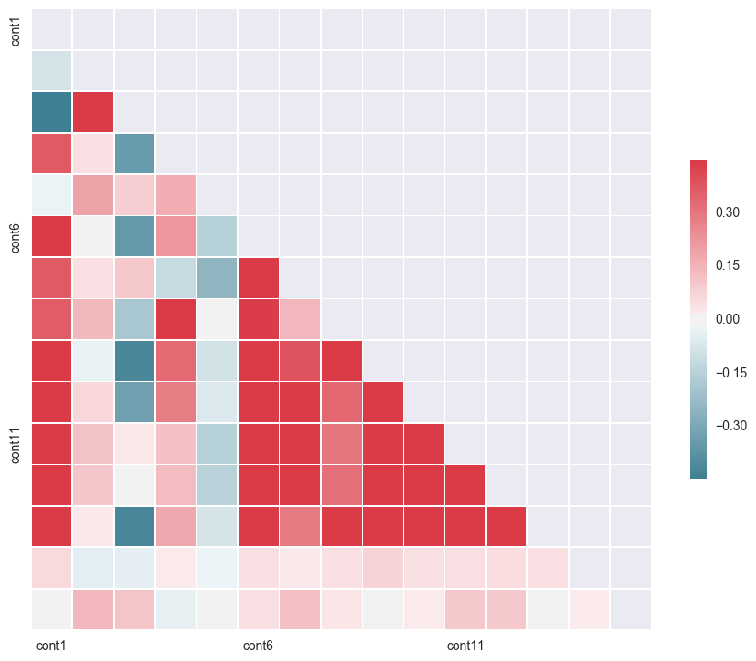

```python
#quick! make a pretty graph so u can use some quant vars tuh
conts = [i for i in dt.columns if "cont" in i]
conts.append('loss')
qu = dt[conts]

corr = qu.corr()

#I stole the rest from seaborn docs:
#http://seaborn.pydata.org/examples/many_pairwise_correlations.html
# Generate a mask for the upper triangle
mask = np.zeros_like(corr, dtype=np.bool)
mask[np.triu_indices_from(mask)] = True

# Set up the matplotlib figure
f, ax = plt.subplots(figsize=(11, 9))

# Generate a custom diverging colormap
cmap = sns.diverging_palette(220, 10, as_cmap=True)

# Draw the heatmap with the mask and correct aspect ratio
sns.heatmap(corr, mask=mask, cmap=cmap, vmax=.3,
            square=True, xticklabels=5, yticklabels=5,
            linewidths=.5, cbar_kws={"shrink": .5}, ax=ax)
```

The last row of the graph is the correlation to loss

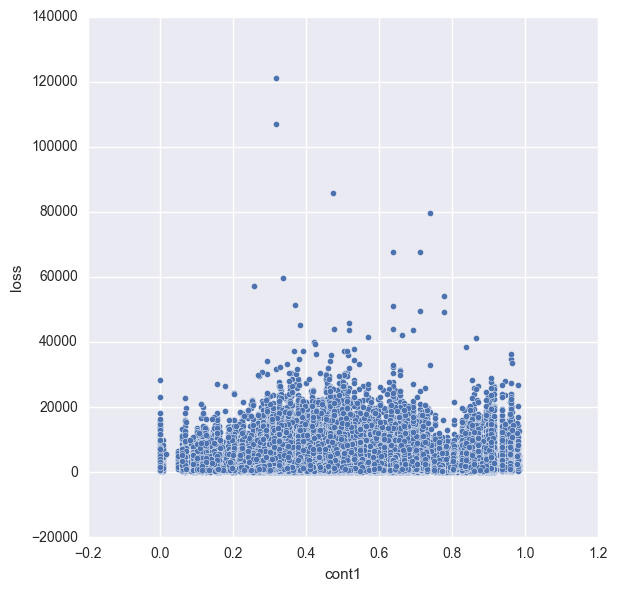

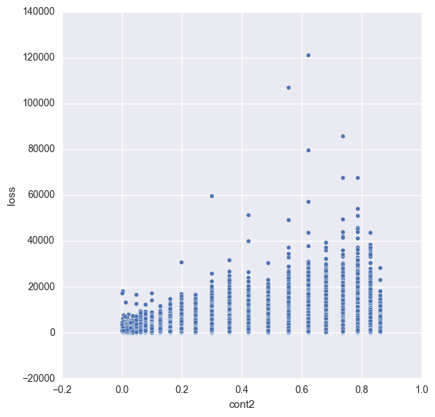

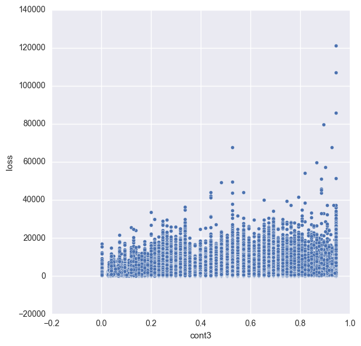

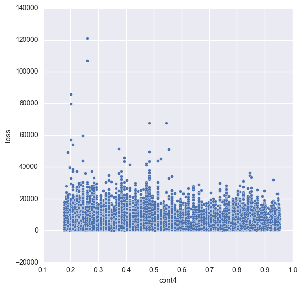

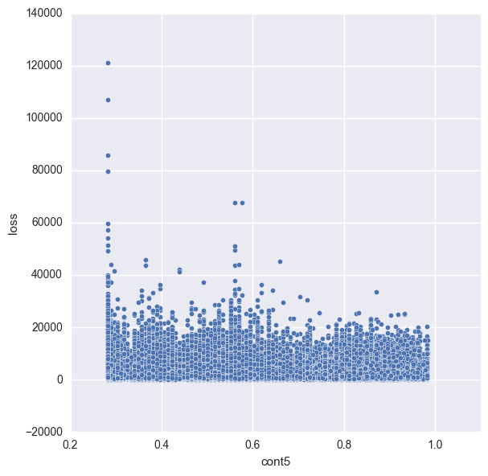

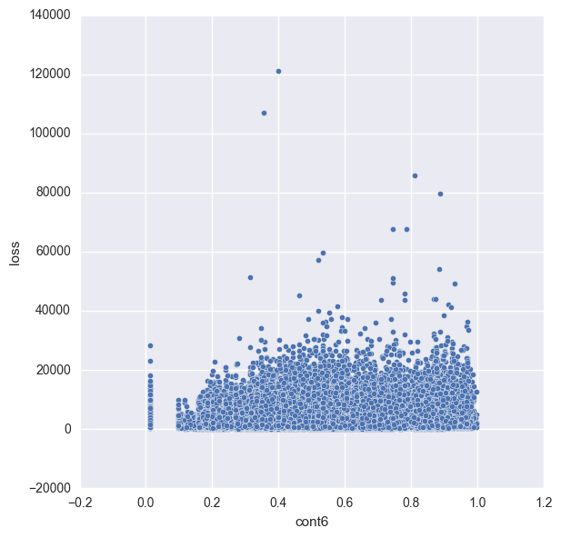

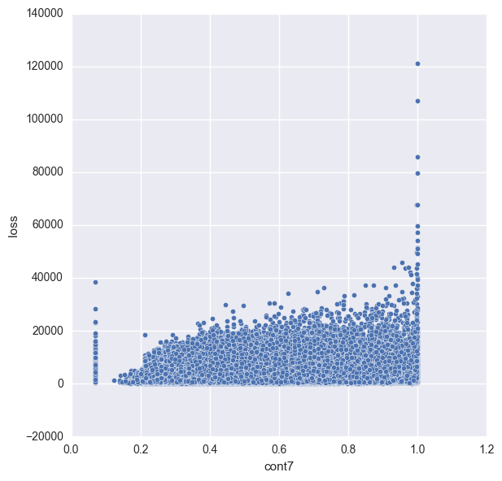

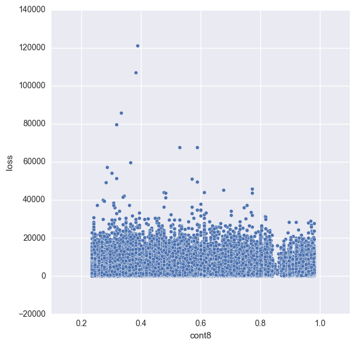

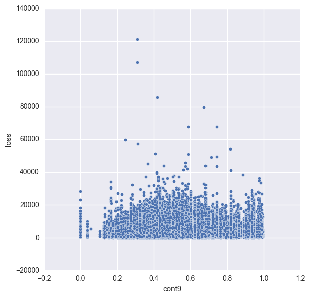

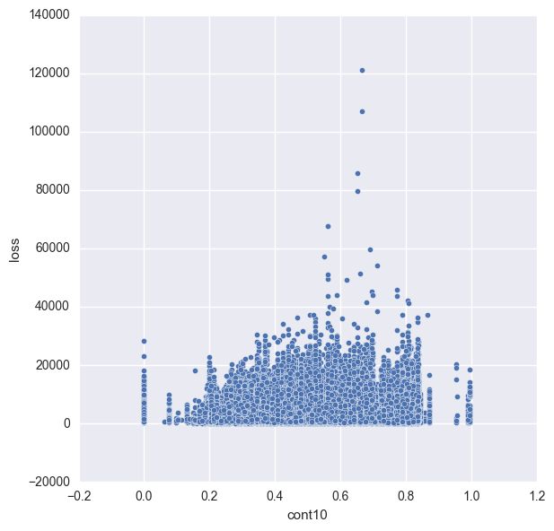

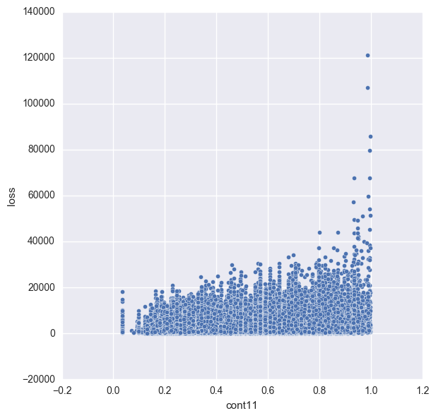

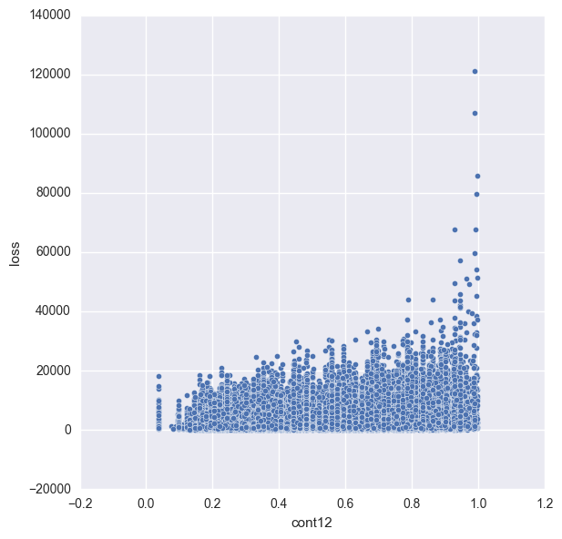

[2 more figures not shown]

```python
for i in [i for i in dt.columns if "cont" in i]:
    sns.pairplot(dt, size=6, x_vars=i,y_vars='loss' )
    plt.show()
```

```python
#get rid of the highly correlated vars
conts = [i for i in conts if i not in ['cont1', 'cont12', 'cont6', 'loss']]

v.extend(conts)

X = dt[v].values
y = dt.loss
```

```python
%%time
from sklearn.model_selection import train_test_split
from sklearn.metrics import mean_absolute_error

Xtr, Xts, ytr, yts = train_test_split(X,y)

from sklearn import linear_model
reg = linear_model.Lasso(alpha=1)
```

```
Wall time: 1min 12s
```

```python
#calculate loss
y_pred = reg.fit(Xtr, ytr).predict(Xts)
mean_absolute_error(yts, y_pred)
```

```
1330.9189914644753
```

So from a simple model we get decent loss training and testing wise compared to the leader board, but thats not super great, lets try harder.

Check out the second notebook for a deep learning implementation of this regresson problem.